# Introdução ao pacote `naniar` para tratamento de NA’s

Pacote `naniar`

Ana Carolina Cavallo e Gabriel Miranda

16/08/2021

No mundo real, é muito comum que as bases de dados não sejam totalmente preenchidas quando criadas. Sendo assim, na análise de dados, nos deparamos com a necessidade de investigar os dados faltantes.

O `R` possui um pacote capaz de auxiliar nessa tarefa. O pacote `naniar` possui diversas funções para tal finalidade. Aqui trataremos das principais ferramentas.

# 1 - Primeiros passos

##### 1.1 - Carregando os pacotes necessários

```r
library(tidyverse)
library(naniar)
```

##### 1.2 - Lendo a base de dados

```r
df = read_csv("german_credit_risk_target.csv")

head(df)
```

```
## # A tibble: 6 x 11
##    ...1   Age Sex      Job Housing `Saving accounts` `Checking account`
##   <dbl> <dbl> <chr>  <dbl> <chr>   <chr>             <chr>
## 1     0    67 male       2 own     <NA>              little
## 2     1    22 female     2 own     little            moderate
## 3     2    49 male       1 own     little            <NA>
## 4     3    45 male       2 free    little            little
## 5     4    53 male       2 free    little            little
## 6     5    35 male       1 free    <NA>              <NA>
## # ... with 4 more variables: Credit amount <dbl>, Duration <dbl>,
## #   Purpose <chr>, Risk <chr>
```

A base de dados possui 11 variáveis referentes a informações bancárias. Algumas delas são:

- Sex: Sexo do cliente;
- Age: Idade do cliente;
- Saving accounts: Conta Poupança;
- Checking account: Conta Corrente;
- Duration: Duração do empréstimo, em meses.

# 2 - Funções

##### 2.1 - Algumas funções primárias

Inicialmente, pode ser interessante realizar uma rápida análise a cerca dos dados faltantes. Para tal tarefa, existem algumas funções que retornam valores que podem auxiliar nessas análises preliminares.

```r
# Total de células com dados faltantes

# Obs: Total de células na base de dados - Número de Linhas x Número de Colunas
# 1000 x 11 = 11000

n_miss(df)
```

```
## [1] 577
```

```r
# Total de células sem dados faltantes
n_complete(df)
```

```
## [1] 10423
```

```r
# Total de variáveis com dados faltantes
n_var_miss(df)
```

```
## [1] 2
```

```r
# Quais variáveis possuem NA's
miss_var_which(df)
```

```
## [1] "Saving accounts"  "Checking account"
```

```r
# Proporção de variáveis com dados faltantes
prop_miss_var(df)
```

```
## [1] 0.1818182
```

##### 2.2 - A função `gg_miss_var()`

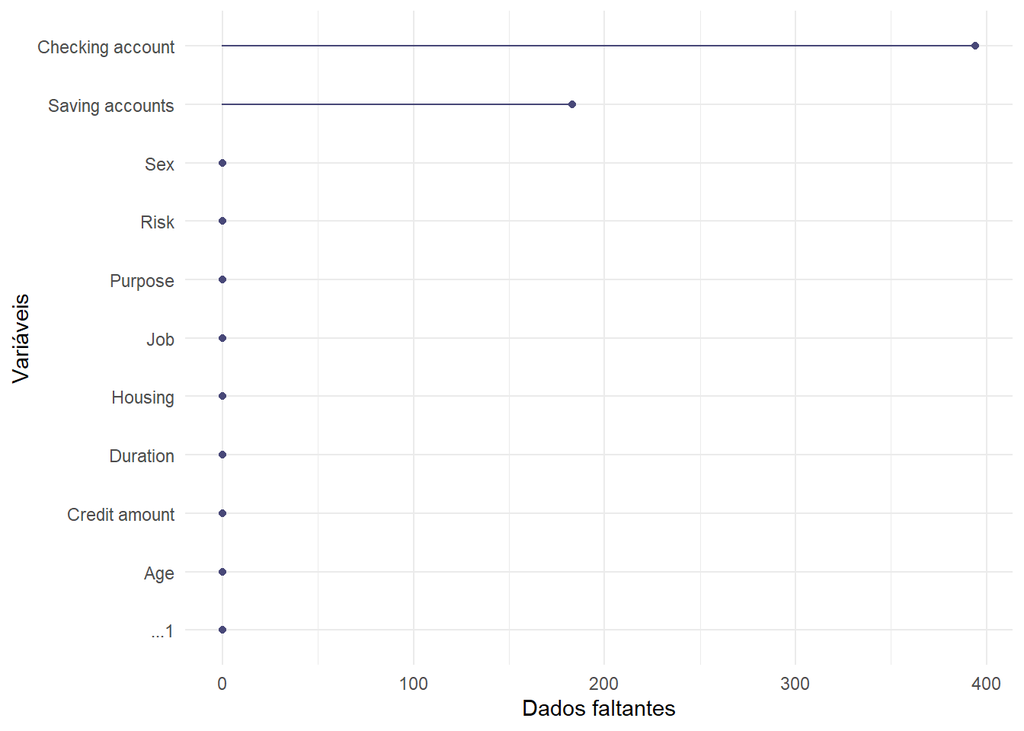

```r
gg_miss_var(df) +
  # Função labs() do pacote ggplot2(tidyverse) para editar o nome dos eixos
  labs(x = "Variáveis",
       y = "Dados faltantes")
```

A função `gg_miss_var()` nos mostra a quantidade de dados faltantes em todas as variáveis da base de dados.

Outros argumentos podem ser úteis para:

- Agrupar em relação a uma outra variável, com o argumento `facet`;
- Mostrar a porcentagem de dados faltantes em cada variável, com o argumento `show_pct`.

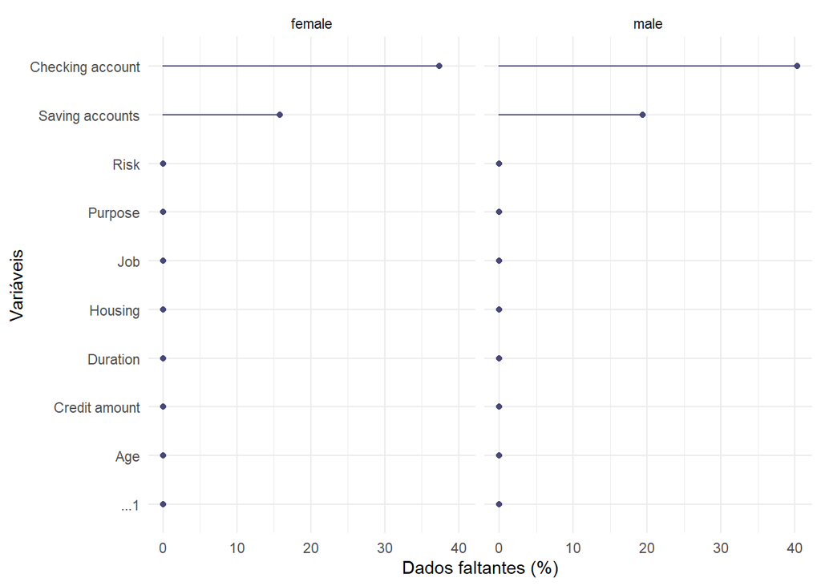

```r
gg_miss_var(df,
            show_pct = TRUE,
            facet = Sex) +
  labs(x = "Variáveis",
       y = "Dados faltantes (%)")
```

##### 2.3 - A função `gg_miss_upset()`

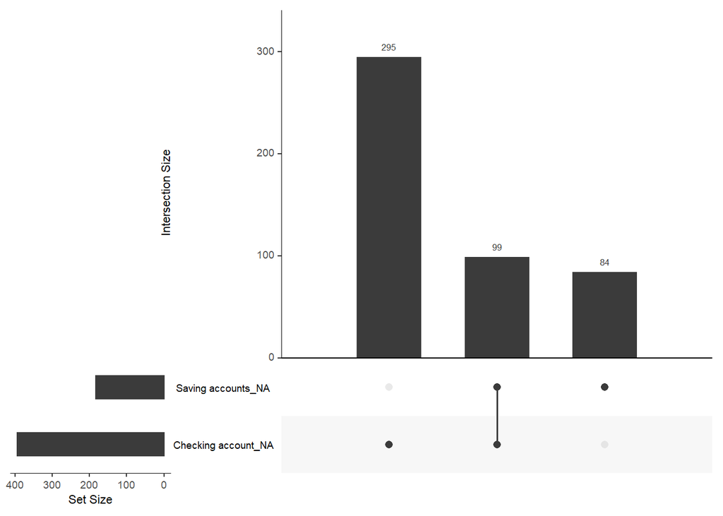

```r
gg_miss_upset(df)
```

A função `gg_miss_upset()` nos mostra quais variáveis possuem dados faltantes, a quantidade de cada uma separadamente e sua intersecção.

Pode-se fazer alterações com as seguintes finalidades:

- Alterar a cor das barras do gráfico, com o argumento `main.bar.color`;
- Alterar a cor do indicador de variável, com o argumento `matrix.color`;
- Alterar a cor da legenda do quantitativo, com o argumento `sets.bar.color`;
- Alterar o nome do eixo y, com o argumento `mainbar.y.label`;
- Alterar o nome da legenda do quantitativo, com o argumento `sets.x.label`;
- Alterar a ordem das barras do gráfico de decrescente para crescente, com o argumento `decreasing = F`.

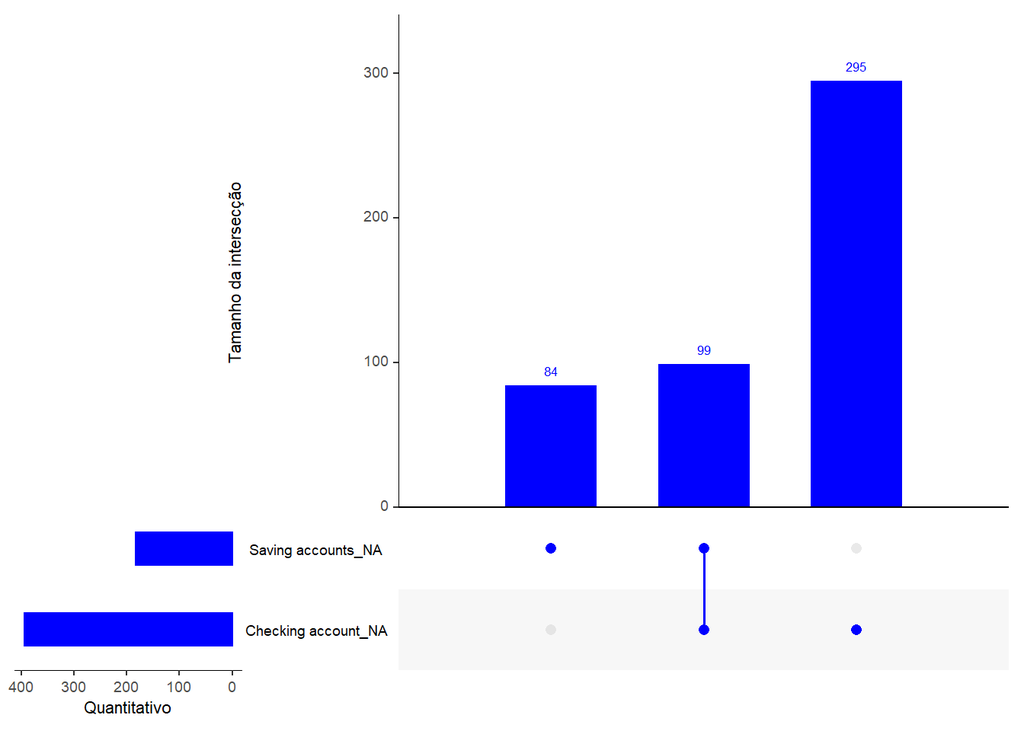

```r
gg_miss_upset(df,
              main.bar.color = "blue",
              matrix.color = "blue",
              sets.bar.color = "blue",
              mainbar.y.label = "Tamanho da intersecção",
              sets.x.label = "Quantitativo",
              decreasing = F)
```

##### 2.4 - A função `vis_miss()`

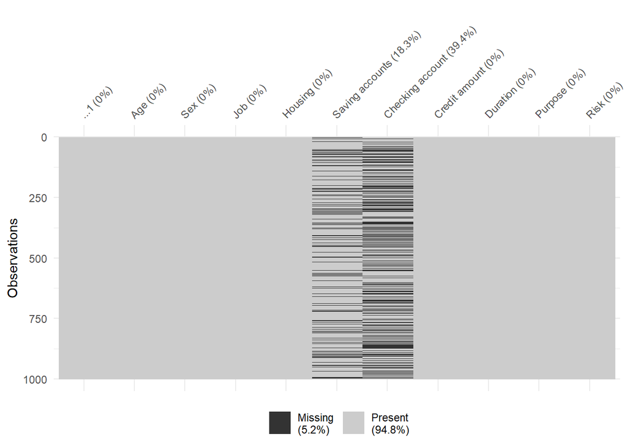

```r
vis_miss(df)
```

A função `vis_miss` nos mostra a porcentagem de *NA’s* presentes na base e uma visualização gráfica dos *NA’s* em cada variável, sendo possível identificar a posição desse dado faltante.

Pode-se fazer alterações com as seguintes finalidades:

- Reordernar de forma decrescente pelo número de *NA’s*, com o argumento `sort_miss = T`;
- Ocultar a porcentagem de *NA’s* em cada coluna, com o argumento `show_perc_col = F`.

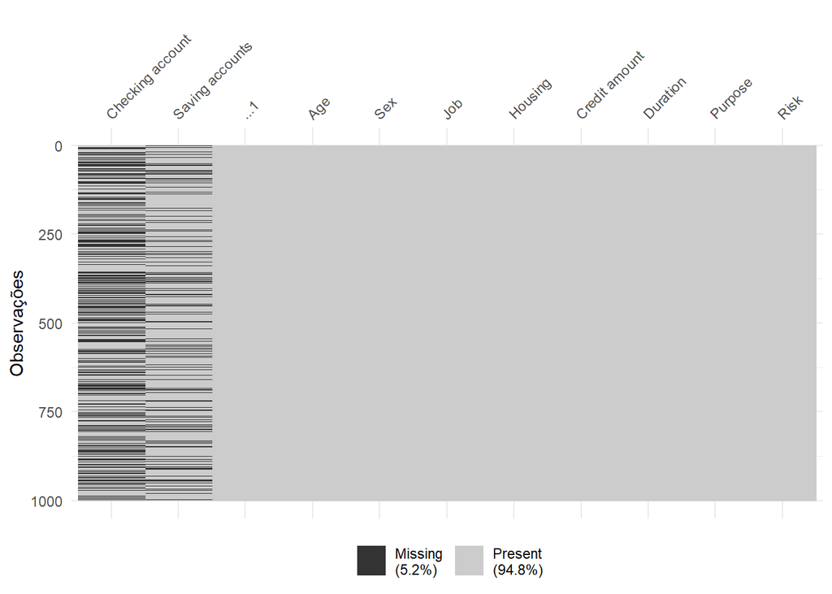

```r
vis_miss(df,
         sort_miss = T,
         show_perc_col = F) +
  labs(y = "Observações")
```

##### 2.5 - A função `add_any_miss()`

```r
df_2 = add_any_miss(df)
head(df_2$any_miss_all)
```

```
## [1] "missing"  "complete" "missing"  "complete" "complete" "missing"
```

A função `add_any_miss()` cria uma nova variável na base de dados, que indica se existe algum dado faltante na observação (linha).

Pode-se fazer alterações com as seguintes finalidades:

- Nomear a nova variável, com o argumento `label`;
- Alterar o nome das categorias, com os argumentos `missing` e `complete` .

```r
df_2 = add_any_miss(df,
                    label = "Possui NA?",
                    missing = "Sim",
                    complete = "Não")
head(df_2$`Possui NA?_all`)
```

```
## [1] "Sim" "Não" "Sim" "Não" "Não" "Sim"
```